# Lab 1 — Introduction to R

Quantitative Reasoning · LAB 413

Instructor: Subin Na

September 3, 2025

> **How to use this document.** Make notes on your own! Comments start with `#` (R ignores them). Actually run the code along with me. Each section mirrors the live lab; code chunks show the command and its output together.

**Today’s plan**

1. Getting started with RStudio
2. Installing & loading packages
3. Working directory setup
4. Basic R commands
5. Working with data frames
6. Histograms and boxplots
7. Visualization with `ggplot2`

# 1 Getting Started with RStudio

RStudio is organized into **four panes**: Source | Console | Environment | Files/Plots/Packages/Help.

> **Tip.** Customize RStudio under **Tools → Global Options → Appearance / Pane Layout**.

**Running code.** Click the **Run** button, or use the keyboard shortcuts:

- Mac: `cmd + return`
- Windows: `ctrl + enter`
- If your cursor is anywhere on a single line, RStudio executes just that line.
- If you highlight (select) multiple lines, RStudio executes the whole selected block.

# 2 Installing & Loading Packages

R packages extend the functionality of R by providing extra functions, data, and documentation. There are over 20,000 packages, but you only need a handful for most work. You don’t need to install everything in advance — just install packages as you need them.

**Install packages** (need quotes because it’s a string). You only need to do this **once**, so these commands are shown but not run when knitting:

```r
install.packages("ggplot2")
install.packages("here")
install.packages("tidyverse")
install.packages("readxl")
install.packages("gapminder")
install.packages("forcats")
```

**Load packages** (no quotes needed — the package name is treated as a symbol). Do this **every time** you start a new session:

```r
library(ggplot2)
library(gapminder)
```

> Remember: - Install only once. No need to reinstall each time you open R. - Load every time you start a new project or session.

> The `here`, `tidyverse`, `readxl`, and `forcats` packages are also useful for managing file paths, data manipulation, reading Excel files, and working with categorical (factor) variables.

# 3 Working Directory Setup

Always set your working directory first. This tells R where to look for files and save outputs.

```r
# What is your current working directory?
getwd()

# Set it to the folder that holds your data files:
setwd("path/to/your/Lab1")
getwd()   # double check
```

> In the live session we set the working directory with `setwd(...)`. In this document the data files sit next to the `.Rmd`, so no `setwd()` is needed.

# 4 Basic R Commands

You can use R as a **calculator**. Be careful: R is **case sensitive** — `a` and `A` are treated as different variables (so `blue`, `Blue`, and `BLUE` are three different names).

```r
a <- 3
A <- 4
a
```

```
#> [1] 3
```

```r
A
```

```
#> [1] 4
```

```r
2 + 2
```

```
#> [1] 4
```

```r
10 - 4
```

```
#> [1] 6
```

```r
3 * 4
```

```
#> [1] 12
```

```r
12 / 3
```

```
#> [1] 4
```

```r
a + A
```

```
#> [1] 7
```

**Vectors** are the most basic data structure in R: an ordered list of values (order matters!).

```r
x <- c(1, 3, 5)
y <- c("hello", "puppy")   # character

x[2]
```

```
#> [1] 3
```

```r
y[2]
```

```
#> [1] "puppy"
```

**Functions.**

```r
mean(x)
```

```
#> [1] 3
```

```r
sqrt(A)
```

```
#> [1] 2
```

Use `?command` (or `help(command)`) to get help in RStudio:

```r
?mean
help(sqrt)
```

# 5 Working with Data Frames

## 5.1 Loading a dataset

**`.rda` files** are the R-native format (rda stands for RData). Read them with `load()`, which puts the dataset into your Environment under its original name.

```r
load("EG01-19COLLEGE.rda")

# rename dataset: newname <- oldname
mydata <- `EG01-19COLLEGE`
```

**`.csv` files** are spreadsheets saved as plain text with comma-separated values — the most common data format in data science. Read them with `read.csv()`.

```r
df <- read.csv("EG01-19COLLEGE.csv", header = TRUE)
# header = TRUE: treat the first row as column names instead of data values
```

> **Simple way to load a dataset in RStudio:** File → Open File → click the `.RData` or `.csv` file.

```r
# remove datasets from memory
rm(`EG01-19COLLEGE`)
rm(mydata)
```

## 5.2 Explore the data frame

In RStudio you would run `View(df)`; here we preview the first rows instead.

```r
knitr::kable(head(df), caption = "First rows of the College data")
```

First rows of the College data

| State | Undergrads | Population | UGradPerThou |
| --- | --- | --- | --- |
| New Jersey | 326358 | 8640218 | 37.77196 |
| Nevada | 100760 | 2484196 | 40.56041 |
| Alaska | 27463 | 676301 | 40.60766 |
| Georgia | 378947 | 9318715 | 40.66516 |
| Connecticut | 142926 | 3487896 | 40.97771 |
| Tennessee | 250974 | 6068306 | 41.35816 |

**Structure & preview.**

```r
str(df)        # structure: types + sample values
```

```
#> 'data.frame':    50 obs. of  4 variables:
#>  $ State       : chr  "New Jersey" "Nevada" "Alaska" "Georgia" ...
#>  $ Undergrads  : int  326358 100760 27463 378947 142926 250974 775171 187254 58512 57527 ...
#>  $ Population  : int  8640218 2484196 676301 9318715 3487896 6068306 18019093 4324799 1313355 1275264 ...
#>  $ UGradPerThou: num  37.8 40.6 40.6 40.7 41 ...
```

```r
head(df)       # first six rows
```

|  | State | Undergrads | Population | UGradPerThou |
| --- | --- | --- | --- | --- |
| 1 | New Jersey | 326358 | 8640218 | 37.77196 |
| 2 | Nevada | 100760 | 2484196 | 40.56041 |
| 3 | Alaska | 27463 | 676301 | 40.60766 |
| 4 | Georgia | 378947 | 9318715 | 40.66516 |
| 5 | Connecticut | 142926 | 3487896 | 40.97771 |
| 6 | Tennessee | 250974 | 6068306 | 41.35816 |

```r
df$State       # access a column by name
```

```
#>  [1] "New Jersey"     "Nevada"         "Alaska"         "Georgia"
#>  [5] "Connecticut"    "Tennessee"      "Florida"        "South Carolina"
#>  [9] "Maine"          "Hawaii"         "New Hampshire"  "Montana"
#> [13] "Maryland"       "Louisiana"      "Oregon"         "Mississippi"
#> [17] "Ohio"           "Arkansas"       "Pennsylvania"   "Texas"
#> [21] "New York"       "Alabama"        "West Virginia"  "Idaho"
#> [25] "North Carolina" "Washington"     "Delaware"       "Indiana"
#> [29] "Virginia"       "Oklahoma"       "Massachusetts"  "Kentucky"
#> [33] "Missouri"       "Colorado"       "Illinois"       "Wisconsin"
#> [37] "Michigan"       "South Dakota"   "Minnesota"      "Vermont"
#> [41] "New Mexico"     "Nebraska"       "California"     "Wyoming"
#> [45] "Kansas"         "Rhode Island"   "North Dakota"   "Utah"
#> [49] "Iowa"           "Arizona"
```

**Size / dimension.**

```r
dim(df)        # rows x columns
```

```
#> [1] 50  4
```

```r
nrow(df)       # number of rows
```

```
#> [1] 50
```

```r
ncol(df)       # number of columns
```

```
#> [1] 4
```

**Names.**

```r
names(df)      # variable names
```

```
#> [1] "State"        "Undergrads"   "Population"   "UGradPerThou"
```

```r
colnames(df)   # same as names()
```

```
#> [1] "State"        "Undergrads"   "Population"   "UGradPerThou"
```

```r
rownames(df)   # row names (rarely needed)
```

```
#>  [1] "1"  "2"  "3"  "4"  "5"  "6"  "7"  "8"  "9"  "10" "11" "12" "13" "14" "15"
#> [16] "16" "17" "18" "19" "20" "21" "22" "23" "24" "25" "26" "27" "28" "29" "30"
#> [31] "31" "32" "33" "34" "35" "36" "37" "38" "39" "40" "41" "42" "43" "44" "45"
#> [46] "46" "47" "48" "49" "50"
```

**Descriptive statistics.**

```r
summary(df)            # summary of all variables
```

```
#>     State             Undergrads        Population        UGradPerThou
#>  Length:50          Min.   :  27463   Min.   :  512573   Min.   :37.77
#>  Class :character   1st Qu.:  90659   1st Qu.: 1771524   1st Qu.:45.73
#>  Mode  :character   Median : 203641   Median : 4221537   Median :49.43
#>                     Mean   : 302136   Mean   : 5955551   Mean   :51.45
#>                     3rd Qu.: 333223   3rd Qu.: 6422700   3rd Qu.:54.46
#>                     Max.   :2172354   Max.   :36121296   Max.   :77.13
```

```r
summary(df$Population) # summary of one column
```

```
#>     Min.  1st Qu.   Median     Mean  3rd Qu.     Max.
#>   512573  1771524  4221537  5955551  6422700 36121296
```

```r
mean(df$Population)
```

```
#> [1] 5955551
```

```r
median(df$Population)
```

```
#> [1] 4221537
```

```r
min(df$Population)
```

```
#> [1] 512573
```

```r
max(df$Population)
```

```
#> [1] 36121296
```

> **Try it.** What is the mean of the undergrad population in the dataset? What about the median? (Type your own code.)

# 6 Histograms and Boxplots

## 6.1 Base R plots

**Histograms** (continuous variables) show the distribution of a variable — are values concentrated, spread out, or skewed?

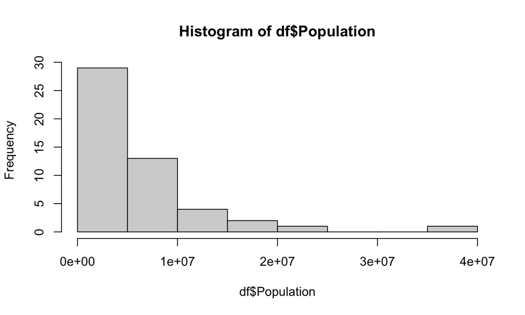

```r
hist(df$Population)                     # basic
```

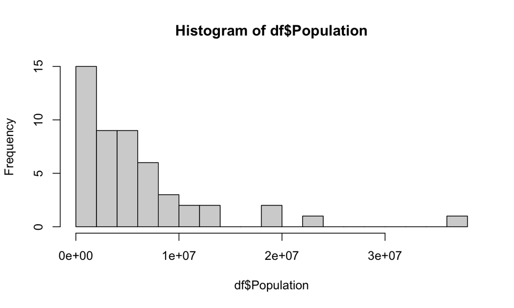

```r
hist(df$Population, breaks = 20)        # adjust number of bins
```

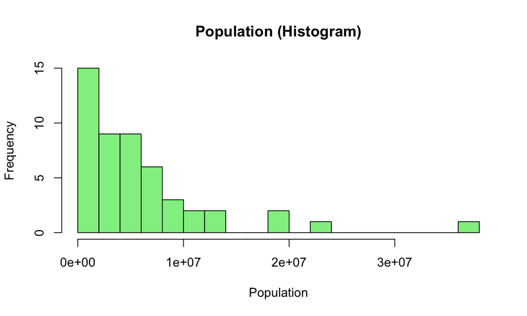

```r
hist(df$Population, main = "Population (Histogram)",
     xlab = "Population", ylab = "Frequency", col = "lightgreen", breaks = 20)
```

**Boxplots** show the median, lower and upper quartiles, and outliers.

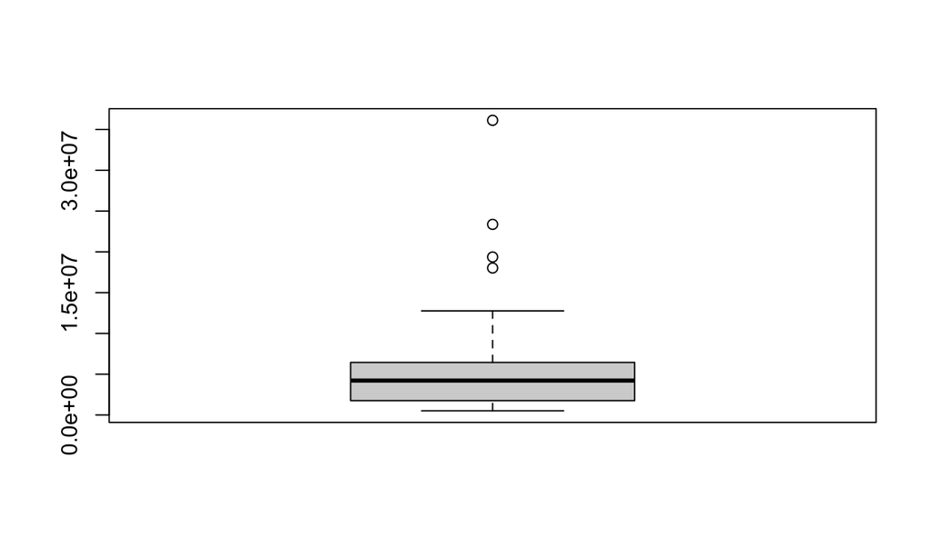

```r
boxplot(df$Population)                  # basic vertical
```

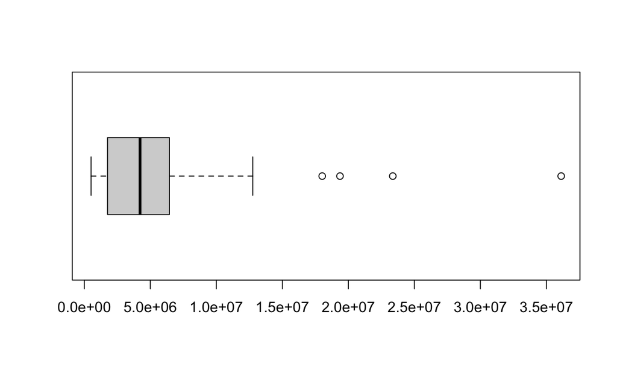

```r
boxplot(df$Population, horizontal = TRUE)   # horizontal style
```

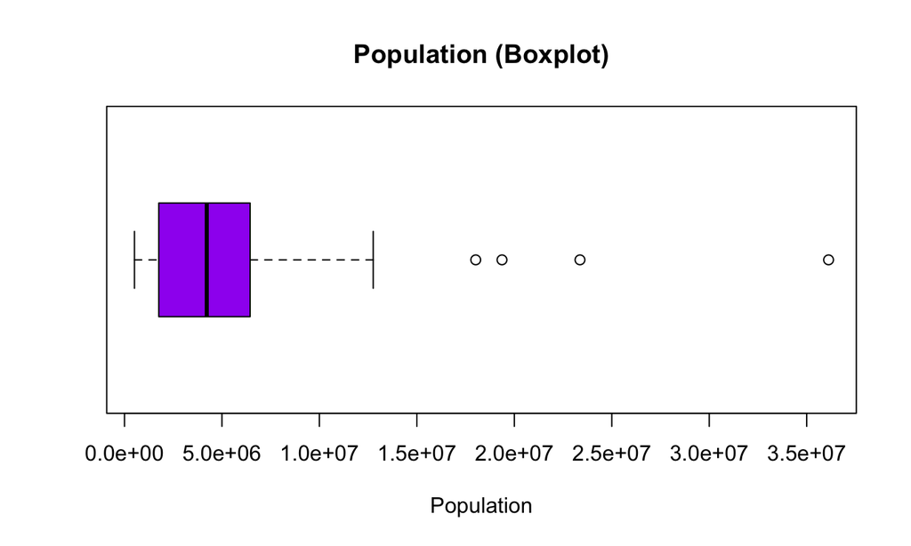

```r
boxplot(df$Population, horizontal = TRUE,
        main = "Population (Boxplot)",
        xlab = "Population", col = "purple")
```

# 7 Visualization with ggplot2

Build plots layer by layer: start with data + `aes()` + geoms. `ggplot2` implements the **grammar of graphics** — use `+` to add layers, and order matters!

## 7.1 Scatterplot (Gapminder dataset)

Goal: explore the relationship between GDP per capita and life expectancy.

```r
gm <- gapminder
```

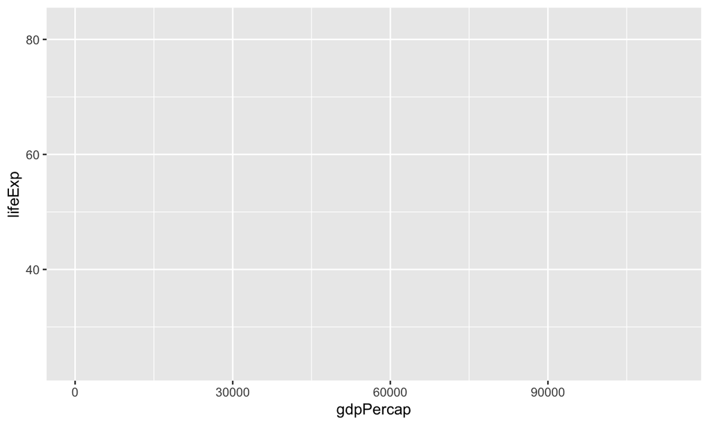

```r
ggplot(data = gm, aes(x = gdpPercap, y = lifeExp))          # start with data + aes
```

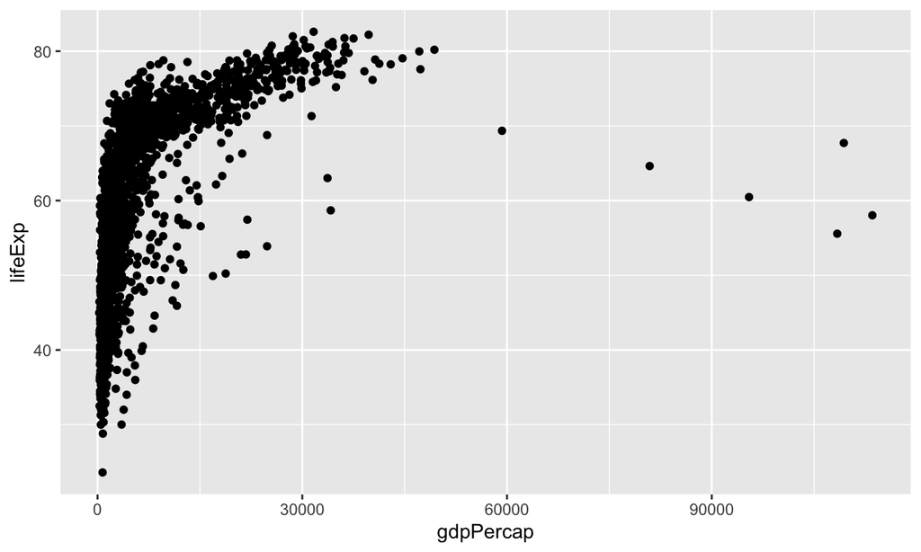

```r
ggplot(data = gm, aes(x = gdpPercap, y = lifeExp)) +
  geom_point()                                       # add scatter points
```

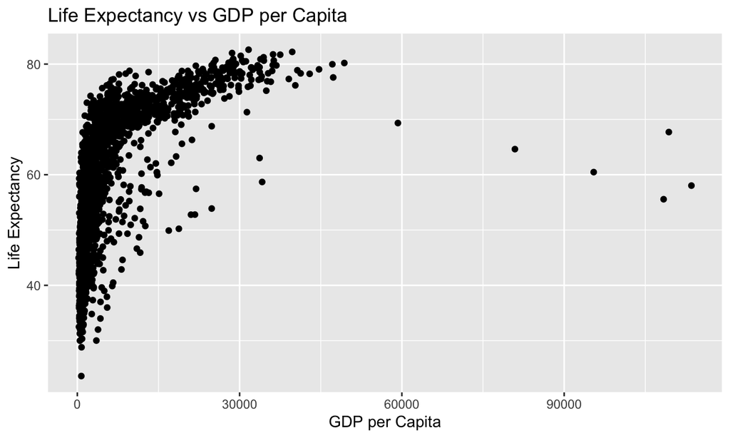

```r
ggplot(data = gm, aes(x = gdpPercap, y = lifeExp)) +
  geom_point() +
  labs(title = "Life Expectancy vs GDP per Capita",  # add title + labels
       x = "GDP per Capita", y = "Life Expectancy")
```

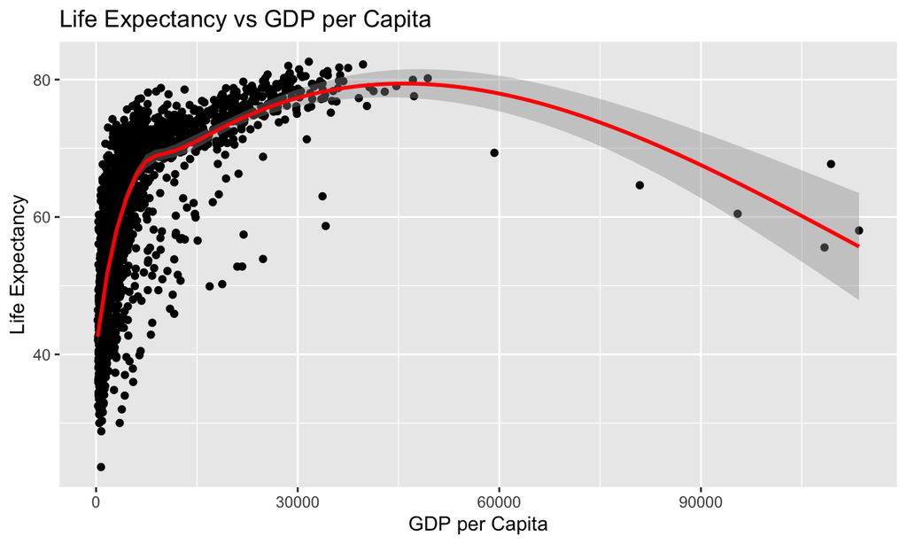

```r
ggplot(data = gm, aes(x = gdpPercap, y = lifeExp)) +
  geom_point() +
  labs(title = "Life Expectancy vs GDP per Capita",
       x = "GDP per Capita", y = "Life Expectancy") +
  geom_smooth(color = "red")                        # add smooth trend line
```

```r
# Note: grey shading = confidence interval
```

## 7.2 Histogram (continuous variable)

Show the distribution of `Population`.

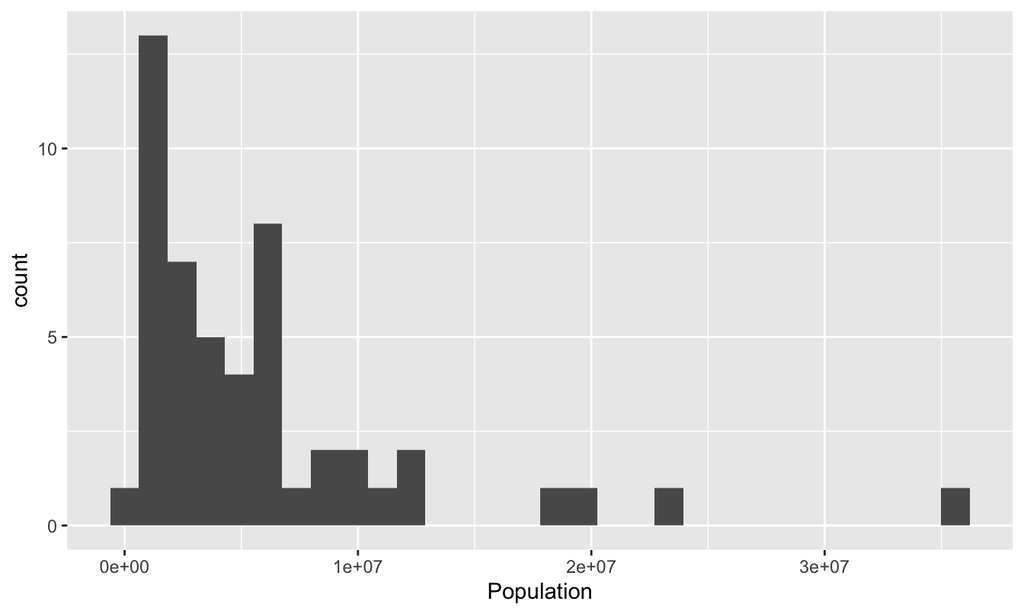

```r
ggplot(data = df, aes(x = Population)) +
  geom_histogram()                                   # basic histogram
```

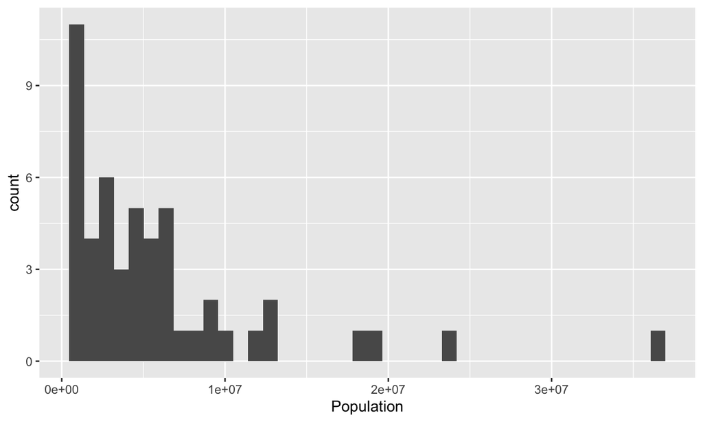

```r
ggplot(data = df, aes(x = Population)) +
  geom_histogram(bins = 40)                          # adjust number of bins
```

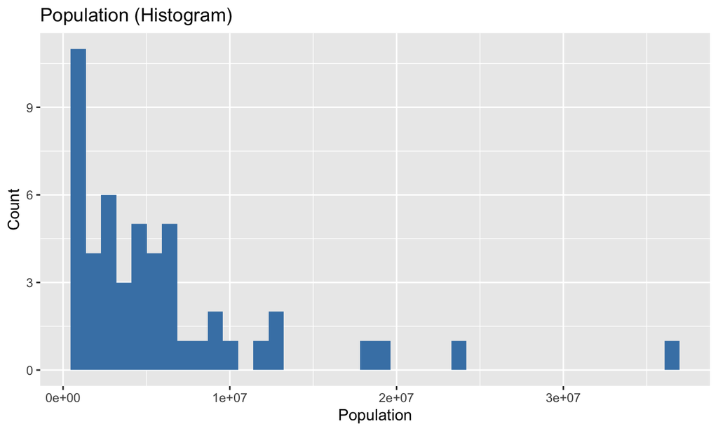

```r
ggplot(df, aes(x = Population)) +
  geom_histogram(bins = 40, fill = "steelblue") +    # add color
  labs(title = "Population (Histogram)", x = "Population", y = "Count")
```

## 7.3 Bar chart (categorical variable)

Load a second dataset and draw a bar chart of search sources.

```r
load("EG01-07ONLINE.rda")
df2 <- `EG01-07ONLINE`   # renaming the data frame
```

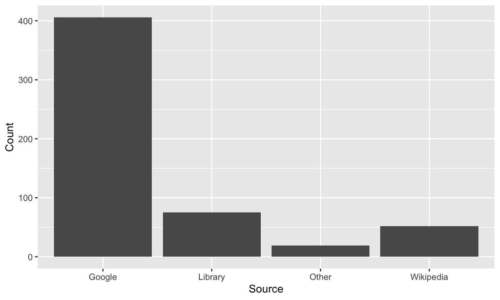

```r
ggplot(df2, aes(x = Source, y = Count)) +
  geom_bar(stat = "identity")   # basic bar chart
```

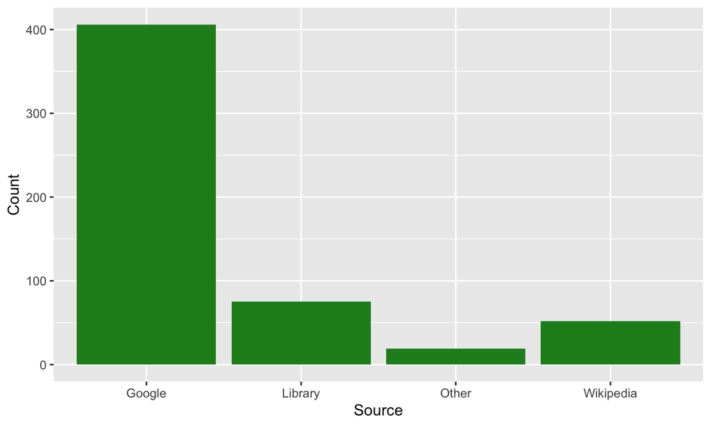

```r
ggplot(data = df2, aes(x = Source, y = Count)) +
  geom_bar(stat = "identity", fill = "forestgreen")   # add color
```

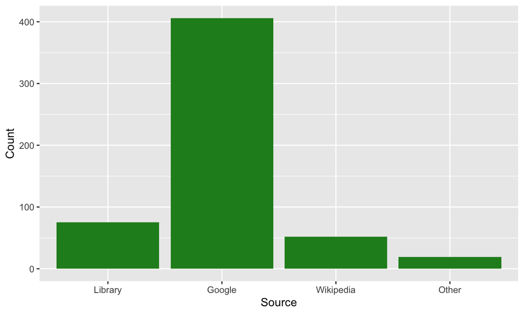

```r
# change the order of the bars
order <- c("Library", "Google", "Wikipedia", "Other")

ggplot(data = df2, aes(x = Source, y = Count)) +
  geom_bar(stat = "identity", fill = "forestgreen") +
  scale_x_discrete(limits = order)
```